# Ford GoBike System Data Exploration

> BY ABDULRAHEEM BASHIR

## Investigation Overview

In this investigation, I wanted to look at the characteristics of Members that could be used to predict the categories of sharing bike during trip. The main focus was on the user_type, gender, age, start_station_name, and end_station_name.

## Dataset Overview

This data set includes information about individual rides made in a bike-sharing system covering the greater San Francisco Bay area.

## Association of members categoriy to bike sharing

The records show that subscribers shared bikes, however no consumer ever shared a bike for the duration of a journey. This makes sense because becoming a subscription entails becoming a member of the community, and sharing a bike may be one of the perks of being a subscriber.

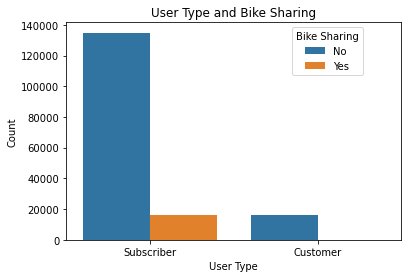

## Majority of Members Category

- The dataset depect that most members are between the ages of 20 and 40.
- The bulk of members are males, accounting for up to 74% of all users, while female members account for approximately 24% of all users.
- Majority of members are subscribers, accounting for up to 90% of all users.

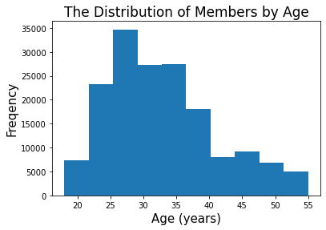

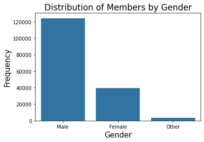

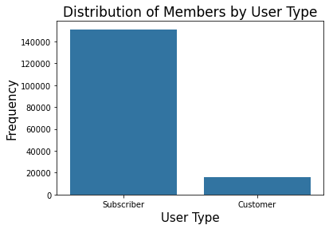

## Top 10 Start and Stop Station

- 'Market ST at 10th St' has the most start trips among the top 10 most common start stations, while 'Stewart St at Market St' has the fewest.
- 'San Francisco Caltrain Station 2 (Townsend St at 4th St' has the most end trips among the top 10 most common end stations, while 'Powell St BART Station (Market St at 5th St)' has the fewest.
- It's also worth noting that 'Market St at 10th St', 'San Francisco Caltrain Station 2 (Townsend St at 4th St)', 'Montgomery St BART Station (Market St at 2nd St)', and 'Powell St BART Station (Market St at 4th St)' all rank in the top 5 for both start and end stations.

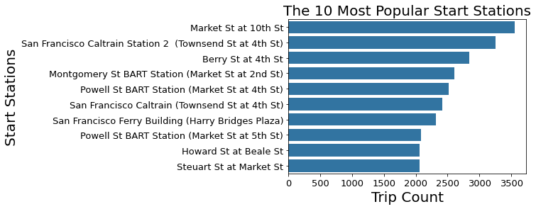

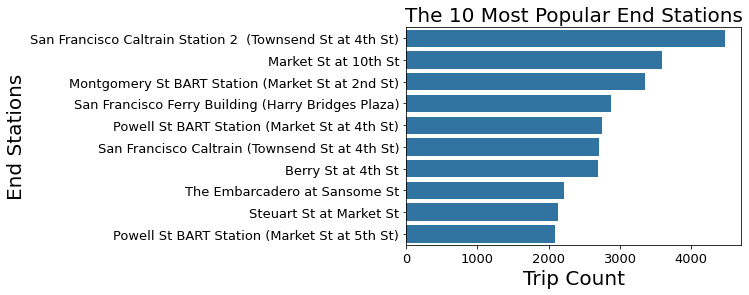